# ranking-ugs — Mapa de capas

Áreas verdes de la Región Metropolitana + capas de apoyo para el ranking

## Cómo leer este mapa

Cada tab agrega, sobre la capa de **áreas verdes de la Región Metropolitana** (MINVU, siempre visible primero, en verde), una capa temática distinta: comparación de fuentes, cobertura pasto/bosque, temperatura por cuartil, buffer de 5 min de Metro, o NDVI. Usar el control de capas (arriba a la derecha de cada mapa) para prender/apagar capas.

**Comparación de fuentes**

Áreas verdes MINVU (verde) vs. áreas verdes “Públicas” de OCUC (naranjo) — ver `data/processed/OCUC-MINVU/README.md`.

[interactive chart not shown]

**Grass / Wood (Dynamic World)**

Probabilidad de cobertura `woody` (trees + shrub_and_scrub) y `grass`, 30m — ver `data/raw/dw-wood-grass/README.md`.

[interactive chart not shown]

**Temperatura Q1-Q4 (stgo-hot)**

Cuartiles de temperatura por período del día — ver `data/processed/stgo-hot/README.md`. Q1 = más frío, Q4 = más caliente **dentro de cada período** (no comparable entre períodos).

[interactive chart not shown]

**Consultar dirección**

Escribe una dirección de Santiago (o haz clic en el mapa) para ver en qué **cuartil de temperatura** (Q1 = más frío … Q4 = más caliente) cae ese punto, en cada período del día — mismos rasters que el tab *Temperatura Q1-Q4*, ver `data/processed/stgo-hot/README.md`. La consulta usa el raster agregado a 30 m (cuartil modal de 3×3 píxeles de 10 m); la dirección se geocodifica con [Nominatim / OpenStreetMap](https://nominatim.org/).

[interactive chart not shown]

**Steinfort 2020**

Propiedades químicas de suelo en 33 plazas y parques de la Región Metropolitana, de Steinfort et al. (2020). Haz clic en un punto para ver todos sus valores. El color del punto indica el contenido de **materia orgánica (OM, %)**. Ver `data/raw/steinfort2020/README.md`.

> Steinfort, U., Contreras, A., Albornoz, F., Reyes-Paecke, S. & Guilleminot, P. (2020). Vegetation survival and condition in public green spaces after their establishment: Evidence from a semi-arid metropolis. *International Journal of Agriculture and Natural Resources*, 47(2). [doi:10.7764/ijanr.v47i2.2045](http://dx.doi.org/10.7764/ijanr.v47i2.2045) · [SciELO](https://www.scielo.cl/article_plus.php?pid=S2452-57312020000200090&tlng=en&lng=es)

[interactive chart not shown]

**5 min Metro**

Buffer de 400m (~5 min caminando) alrededor de cada estación de Metro — ver `data/processed/metro/README.md`. Es un buffer euclidiano recto, no una isócrona de red peatonal.

[interactive chart not shown]

**NDVI**

NDVI de Santiago, enero 2024 (raster con CRS reparado) — ver `data/processed/NDVI/README.md`.

[interactive chart not shown]

**Resumen: plazas vs. parques**

Descriptivos agregados a nivel de plaza/parque (Región Metropolitana) — ver `scripts/10_indicadores_combinados_rm.R` y `data/processed/indicadores/README.md`. Calidad, NDVI, temperatura de tarde (AF) y cobertura woody/grass son promedios por polígono; correr ese script primero si `data/processed/indicadores/` no existe todavía.

| Tipo | N° polígonos | Área media (m²) | Calidad media (0-100) | NDVI medio | Temp. AF media (°C) | Woody medio | Grass medio |
| --- | --- | --- | --- | --- | --- | --- | --- |
| PARQUE | 866 | 22.761 | 62.1 | 0.336 | 31.6 | 0.092 | 0.033 |
| PLAZA | 9.377 | 1.881 | 69.0 | 0.284 | 31.5 | 0.072 | 0.029 |

Cuartiles de calidad (Q1 = más baja, Q4 = más alta) por tipo — ver `data/processed/SHP/README.md` para cómo se calculan:

| Tipo | Q1 | Q2 | Q3 | Q4 | Sin encuesta |
| --- | --- | --- | --- | --- | --- |
| PARQUE | 278 | 160 | 116 | 56 | 256 |
| PLAZA | 1679 | 1773 | 1829 | 1888 | 2208 |

**Qué significa cada cuartil en la práctica** — valor promedio de calidad y de temperatura AF *dentro* de cada cuartil, por tipo (los cortes de cuartil son los mismos para PLAZA y PARQUE — ver `data/processed/indicadores/README.md` — pero el promedio real dentro de cada bloque puede variar levemente según qué polígonos de cada tipo caen ahí):

Calidad promedio (0-100) por cuartil y tipo

| Tipo | Q1 | Q2 | Q3 | Q4 |
| --- | --- | --- | --- | --- |
| PARQUE | 50.2 | 65.9 | 74.7 | 84.2 |
| PLAZA | 49.4 | 66.4 | 74.9 | 83.1 |

Temperatura AF promedio (°C) por cuartil y tipo

| Tipo | Q1 | Q2 | Q3 | Q4 |
| --- | --- | --- | --- | --- |
| PARQUE | 30.7 | 31.3 | 31.7 | 32.4 |
| PLAZA | 30.8 | 31.3 | 31.7 | 32.4 |

**Muestra de terreno (Q1 vs. Q4)**

Muestra aleatoria estratificada de 144 sitios para una campaña de terreno (carbono en el suelo) — estratificada por `TIPO_EP` × **extremos** (Q1 y Q4, no los 4 cuartiles) de calidad y de temperatura AF, para maximizar el contraste entre esas variables. **No** es un “top N” por puntaje: un sitio puede rankear muy bien en el compuesto general (ver `data/processed/indicadores/README.md` para ese ranking completo, `ranking_final_rm.gpkg`) y aun así quedar fuera de esta muestra si su calidad o temperatura caen en el rango medio (Q2/Q3) en vez de en un extremo — le pasa, por ejemplo, al Parque Metropolitano de Santiago, que es #1 del ranking pero su temperatura siempre cae en Q3. Ver `scripts/12_muestra_estratificada_carbono.R` para la metodología completa (diseño inspirado en Vasenev et al. 2014, *Geoderma*).

**Asignación lograda de la muestra estratificada** (objetivo ~18 por celda — subida de 112 a 144 sitios para dejar respaldo por si hay problemas de acceso en terreno — capado por disponibilidad real: las celdas de parques Q4-calidad son muy chicas, solo 5-8 polígonos en toda la RM cumplen calidad alta *y* temperatura extrema, ver README para el detalle):

| Tipo | Cuartil calidad | Cuartil temp. AF | Disponibles | Objetivo | Logrado | Cerca Metro | % cerca Metro |
| --- | --- | --- | --- | --- | --- | --- | --- |
| PARQUE | Q1 | Q1 | 34 | 22 | 22 | 0 | 0.0 |
| PARQUE | Q1 | Q4 | 98 | 22 | 22 | 12 | 54.5 |
| PARQUE | Q4 | Q1 | 8 | 8 | 8 | 1 | 12.5 |
| PARQUE | Q4 | Q4 | 5 | 5 | 5 | 1 | 20.0 |
| PLAZA | Q1 | Q1 | 98 | 22 | 22 | 1 | 4.5 |
| PLAZA | Q1 | Q4 | 298 | 22 | 22 | 16 | 72.7 |
| PLAZA | Q4 | Q1 | 356 | 22 | 22 | 8 | 36.4 |
| PLAZA | Q4 | Q4 | 248 | 21 | 21 | 15 | 71.4 |

**Mapa de la muestra** (144 sitios, color = tipo, forma = cuartil de calidad, superpuestos al cuartil de temperatura de tarde AF):

[interactive chart not shown]

**Muestra completa (144 sitios)**

Los 144 sitios seleccionados, con los niveles de estratificación usados (`Tipo`, `Cuartil calidad`, `Cuartil temp. AF`, `Cerca Metro`) y los indicadores de apoyo. Tabla ordenable/buscable — columnas por las que se estratificó están resaltadas al inicio.

| id | Tipo | Cuartil calidad | Cuartil temp. AF | Cerca Metro | ID MINVU | Área (m²) | Calidad | Temp. AF (°C) | NDVI | Woody | Grass | Puntaje ranking | Posición ranking |
| --- | --- | --- | --- | --- | --- | --- | --- | --- | --- | --- | --- | --- | --- |
| parque_las_pircas | PARQUE | Q1 | Q1 | No | 1312211036 | 26023 | 57.2 | 30.3 | 0.49 | 0.339 | 0.038 | 0.519 | 33 |
| parque_portal_bicentenario_cerrillos | PARQUE | Q1 | Q1 | No | 1310210064 | 81365 | 56.2 | 30.8 | 0.281 | 0.122 | 0.041 | 0.351 | 1411 |
| parque_las_torres | PARQUE | Q1 | Q1 | No | 1310210059 | 8661 | 55.4 | 31 | 0.468 | 0.081 | 0.033 | 0.372 | 874 |
| parque_paseo_del_monasterio | PARQUE | Q1 | Q1 | No | 1311530572 | 2158 | 60.6 | 30.4 | 0.426 | 0.104 | 0.042 | 0.409 | 356 |
| parque_avenida_colon | PARQUE | Q1 | Q1 | No | 1340120449 | 4701 | 60.9 | 31 | 0.284 | 0.062 | 0.027 | 0.32 | 2456 |
| parque_la_aguada | PARQUE | Q1 | Q1 | No | 1310210473 | 22754 | 37.9 | 31.1 | 0.273 | 0.069 | 0.029 | 0.266 | 3791 |
| parque_san_luis_de_orione | PARQUE | Q1 | Q1 | No | 1310210055 | 89711 | 59.8 | 31 | 0.351 | 0.161 | 0.046 | 0.388 | 583 |
| parque_las_torres | PARQUE | Q1 | Q1 | No | 1310210059 | 10676 | 55 | 30.6 | 0.35 | 0.074 | 0.036 | 0.353 | 1364 |
| parque_jardines_de_la_vina | PARQUE | Q1 | Q1 | No | 1311010250 | 6878 | 58.4 | 31.1 | 0.447 | 0.08 | 0.036 | 0.371 | 890 |
| parque_avenida_colon | PARQUE | Q1 | Q1 | No | 1340120449 | 6551 | 56.4 | 30.8 | 0.223 | 0.061 | 0.028 | 0.297 | 3127 |

[output cut: 134 more lines]

**Puntos por UGS (exploratorio)**

> **Exploratorio.** Prueba del paquete soilsampling para ubicar puntos de suelo *dentro* de cada uno de los 144 sitios de la muestra. Todo vive en `scripts/exploratorio_soilsampling/` y se puede borrar junto con la línea `include` en `mapa_ugs.qmd`.

**Cómo se eligió n.** No se usa `ss_kl_size()` (n óptimo por divergencia KL): la mediana de los sitios es ~2.900 m², es decir 1–5 píxeles de 30 m de NDVI/Dynamic World/temperatura, así que dentro de una plaza no hay distribución de covariables que cubrir. En su lugar se usa una **regla por tramo de área** (supuesto, editable en `TRAMOS` del script). Los puntos se ubican con `ss_coverage_equal_area()`: k-means con estratos de **igual área** y un punto en el centroide de cada estrato — sirve tanto para muestras individuales como para **un compuesto por sitio** (una submuestra por estrato, todas con el mismo peso).

| Tramo | n por sitio | Sitios | Plazas | Parques | Puntos totales |
| --- | --- | --- | --- | --- | --- |
| ≤ 0,2 ha | 3 | 48 | 44 | 4 | 144 |
| 0,2–0,5 ha | 4 | 49 | 31 | 18 | 196 |
| 0,5–1 ha | 5 | 20 | 6 | 14 | 100 |
| 1–5 ha | 8 | 21 | 6 | 15 | 168 |
| > 5 ha | 12 | 6 | 0 | 6 | 72 |
| Total |  | 144 | 87 | 57 | 680 |

**Mapa:** polígono de cada sitio, sus estratos de igual área (bordes punteados) y el punto de muestreo de cada estrato. Haz zoom a un sitio para verlo.

[interactive chart not shown]

**Qué debería fijar n en realidad:** la variabilidad del carbono orgánico del suelo (COS) *dentro* del sitio. Con n = (t · CV / E)², donde CV es el coeficiente de variación dentro del sitio y E el error relativo aceptado (95 %, t ≈ 2), el n necesario sería:

|  | E ± 10 % | E ± 15 % | E ± 20 % |
| --- | --- | --- | --- |
| CV 20 % | 16 | 7 | 4 |
| CV 30 % | 35 | 16 | 9 |
| CV 40 % | 62 | 28 | 16 |

Steinfort et al. (2020) tiene un solo valor por plaza, así que solo informa la variabilidad *entre* sitios, no dentro de cada sitio. Para fijar CV haría falta un piloto (muestreo denso en 3–5 sitios) o un valor de literatura para céspedes y parques urbanos.

### Todas las UGS de la RM

La misma regla de n por tramo de área y el mismo método de ubicación (`ss_coverage_equal_area()`), aplicados a **todas las áreas verdes de la RM** (`data/processed/SHP/areas_verdes_rm.gpkg`), no solo a los 144 sitios — ver `puntos_todas_ugs.R`. Son decenas de miles de puntos, así que aquí se muestran resúmenes y un mapa estático (un mapa interactivo con todos los puntos haría fallar el deploy de GitHub Pages por peso); la capa completa queda en `data/processed/exploratorio_soilsampling/puntos_todas_ugs.gpkg`.

| Tramo | n por UGS | UGS | Plazas | Parques | Área total (ha) | Puntos totales |
| --- | --- | --- | --- | --- | --- | --- |
| ≤ 0,2 ha | 3 | 6.978 | 6.769 | 209 | 682 | 20.934 |
| 0,2–0,5 ha | 4 | 2.249 | 2.027 | 222 | 690 | 8.996 |
| 0,5–1 ha | 5 | 595 | 440 | 155 | 411 | 2.975 |
| 1–5 ha | 8 | 373 | 141 | 232 | 705 | 2.984 |
| > 5 ha | 12 | 48 | 0 | 48 | 1.248 | 576 |
| Total |  | 10.243 | 9.377 | 866 | 3.736 | 36.465 |

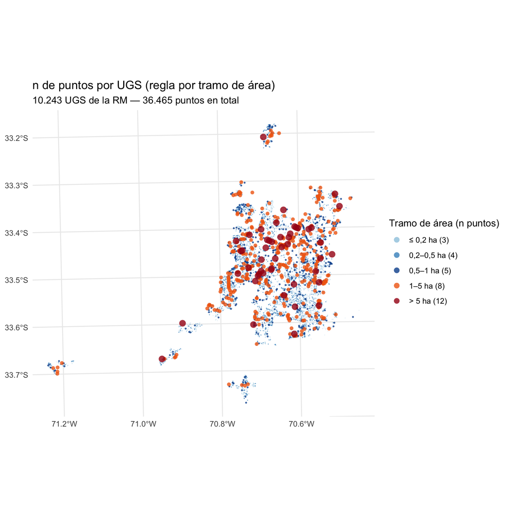

**Cuánto cambia el total según cómo se fije n.** La regla por tramo de área frente a un n fijo por UGS derivado del CV de COS (n = (t · CV / E)², aplicado a cada una de las UGS de la RM):

| Escenario | n por UGS | Puntos totales |
| --- | --- | --- |
| Regla por tramo de área (este tab) | 3–12 | 36.465 |
| CV 20 %, E ± 10 % | 16 | 163.888 |
| CV 30 %, E ± 10 % | 35 | 358.505 |
| CV 40 %, E ± 10 % | 62 | 635.066 |
| CV 20 %, E ± 20 % | 4 | 40.972 |
| CV 30 %, E ± 20 % | 9 | 92.187 |
| CV 40 %, E ± 20 % | 16 | 163.888 |